# 4360 - Blog Project

Ian Thorne

2024-11-19

## Introduction

This analysis focuses on understanding the sentiment and thematic content of annual reports filed by companies. We use text-mining techniques like sentiment analysis, bigram analysis, and topic modeling to uncover patterns and insights.

**Research Questions**: 1. Which companies exhibit the highest and lowest sentiment scores in their annual reports?

hi-20240930: Sentiment score approximately 700.

vrex-20240927: Sentiment score approximately -219.

2. What are the most frequently occurring positive and negative words in these reports?

– Fair, Significant, and Outstanding are top 3 positive

– Debt, risk, loss are top 3 negative

3. What topics dominate the annual reports, and how are they distributed among the companies?

– Topic 1 is balance sheet related

– Topic 2 is income statement related

– Topic 3 is cash flow related

– Topic 4 is Investments and business type related

By answering these questions, we aim to provide actionable insights into how companies communicate their financial performance and prospects.

## Remote Driving

Initializes an RSelenium remote driver to scrape data from the SEC website. The driver is configured to interact with the Firefox browser.

```r
#sec_site <- "https://www.sec.gov/edgar/search/#/category=form-cat1&filter_forms=10-K"


#driver <- rsDriver(browser = "firefox",
                  # chromever = NULL,
                  # verbose = F,
                  # port = free_port())



#remDr <- driver[["client"]]



#remDr$navigate('https://www.sec.gov/edgar/search/#/category=form-cat1&filter_forms=10-K')
```

## CSS Selector

Identifies the HTML elements on the SEC website (e.g., preview buttons) using CSS selectors to navigate through the site and download the necessary data.

```r
#element <- remDr$findElement(using = 'css selector',
                            # ".preview-file") # find selector for button
#next_button <- remDr$findElement(using = 'css selector',
                            #     ".btn-warning")

#close <- remDr$findElement(using = 'css selector',
                        #   '#close-modal')
```

## Get Stock URLs

Automates the process of navigating to the SEC site, clicking preview links, and extracting URLs for the documents of interest.

```r
#stocks <- list()

#for(i in 1:25) {
  # Navigate to the SEC search page
#  remDr$navigate('https://www.sec.gov/edgar/search/#/category=form-cat1&filter_forms=10-K')
  #Sys.sleep(0)  # Give time for the page to load

  # Find and click the i-th preview file link
#  links <- remDr$findElements(using = 'css selector', ".preview-file")
#  links[[i]]$clickElement()
  #Sys.sleep(0)

  # Extract page source and find the document URL
#  stocks[[i]] <- read_html(remDr$getPageSource()[[1]]) %>%
#    html_elements("#open-file") %>%
#    html_attrs() %>%
#    tibble() %>%
#    unnest(cols = c(.)) %>%  # Specify 'cols' to avoid warning
#    filter(str_detect(., "https")) %>%
#    pull(.) %>%
#    unname()

  # Close the preview to return to the main page
#  close_button <- remDr$findElement(using = 'css selector', ".close")
#  close_button$clickElement()
  #Sys.sleep(0)
#}

# Print the test list to check extracted URLs
#print(stocks)

# Close the browser and server when done
#remDr$close()
#driver$server$stop()
```

```r
# Save the list to an RDS file
#saveRDS(stocks, "stocks_.rds")
```

## Scraping the URLs

Uses httr to fetch the HTML content of the downloaded URLs. The data is processed to extract text content from specific HTML elements.

```r
stocks <- readRDS("stocks_.rds")
urls <- unlist(stocks)

library(httr)
df<- list()
for(j in 1:length(urls)){
  x <- GET(urls[j], add_headers('user-agent' = 'student scraping ([[your email]])'))

  df[[j]] <- x %>%
    read_html() %>%
    html_elements("span") %>%
    html_text()
}
```

## Processing the text from the URLs

Cleans and structures the extracted text into a tidy format. Each document is assigned an extracted_name (a unique identifier), and the text is prepared for analysis.

```r
processed_df <- tibble(df) %>%
  mutate(name = urls) %>%
  unnest(df) %>%
  mutate(extracted_name = str_extract(name, "[^/]+(?=\\.htm$)")) %>%
  select(-name)

processed_df
```

```
## # A tibble: 201,510 × 2
##    df                                                             extracted_name
##    <chr>                                                          <chr>
##  1 "10-K"                                                         wdsp_10k23t
##  2 "[X] ANNUAL REPORT PURSUANT TO SECTION 13 OR 15(d) OF THE SEC… wdsp_10k23t
##  3 "[X]"                                                          wdsp_10k23t
##  4 "OCTOBER 31, 2023"                                             wdsp_10k23t
##  5 "[ \t]TRANSITION REPORT PURSUANT TO SECTION 13 OR 15(D) OF TH… wdsp_10k23t
##  6 "000-56208"                                                    wdsp_10k23t
##  7 "World Scan Project, Inc."                                     wdsp_10k23t
##  8 "Delaware"                                                     wdsp_10k23t
##  9 "Delaware"                                                     wdsp_10k23t
## 10 "35-2677532"                                                   wdsp_10k23t
## # ℹ 201,500 more rows
```

## DataFrames

Tokenizes the text into individual words and removes stop words using tidytext. Performs sentiment analysis using the Bing sentiment lexicon. The resulting data includes sentiment scores for each document (sentiment_df).

```r
analyze_df <- processed_df %>%
  unnest_tokens(word, df) %>%
  anti_join(stop_words, by = "word")

analyze_df
```

```
## # A tibble: 772,814 × 2
##    extracted_name word
##    <chr>          <chr>
##  1 wdsp_10k23t    10
##  2 wdsp_10k23t    annual
##  3 wdsp_10k23t    report
##  4 wdsp_10k23t    pursuant
##  5 wdsp_10k23t    section
##  6 wdsp_10k23t    13
##  7 wdsp_10k23t    15
##  8 wdsp_10k23t    securities
##  9 wdsp_10k23t    exchange
## 10 wdsp_10k23t    act
## # ℹ 772,804 more rows
```

```r
sentiment_df <- analyze_df %>%
  inner_join(get_sentiments('bing'), by = 'word') %>%
  count(extracted_name, sentiment) %>%
  pivot_wider(names_from = sentiment, values_from = n, values_fill = 0) %>%
  mutate(sentiment_score = positive - negative)

sentiment_df
```

```
## # A tibble: 23 × 4
##    extracted_name   negative positive sentiment_score
##    <chr>               <int>    <int>           <int>
##  1 acm-20240930x10k      119       72             -47
##  2 adnt-20240930        1110     1353             243
##  3 ash-20240930         1269     1468             199
##  4 ato-20240930          744      875             131
##  5 brbr-20240930         923     1005              82
##  6 cik0-20240927        1174     1156             -18
##  7 dhi-20240930          841     1047             206
##  8 dlb-20240927          845     1083             238
##  9 enr-20240930         1269     1540             271
## 10 ffiv-20240930        1052     1022             -30
## # ℹ 13 more rows
```

```r
view(sentiment_df)
```

## Data Description

```r
# Summary of the data
summary(processed_df)
```

```
##       df            extracted_name
##  Length:201510      Length:201510
##  Class :character   Class :character
##  Mode  :character   Mode  :character
```

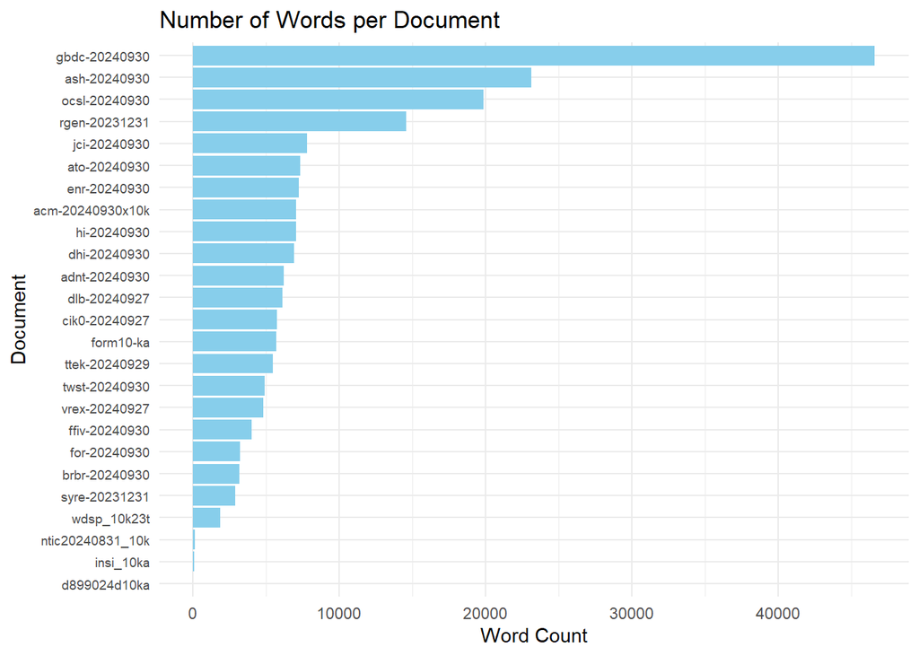

```r
# Plot the number of words per document
processed_df %>%
  count(extracted_name) %>%
  ggplot(aes(x = reorder(extracted_name, n), y = n)) +
  geom_bar(stat = "identity", fill = "skyblue") +
  coord_flip() +
  labs(
    title = "Number of Words per Document",
    x = "Document",
    y = "Word Count"
  ) +
  theme_minimal() +
  theme(
    axis.text.y = element_text(size = 7, angle = 0, hjust = 1)  # Combine all settings here
  )
```

## Sentiment Scores

Visualizes sentiment scores by company in a bar plot. Positive and negative sentiment scores are distinguished by color.

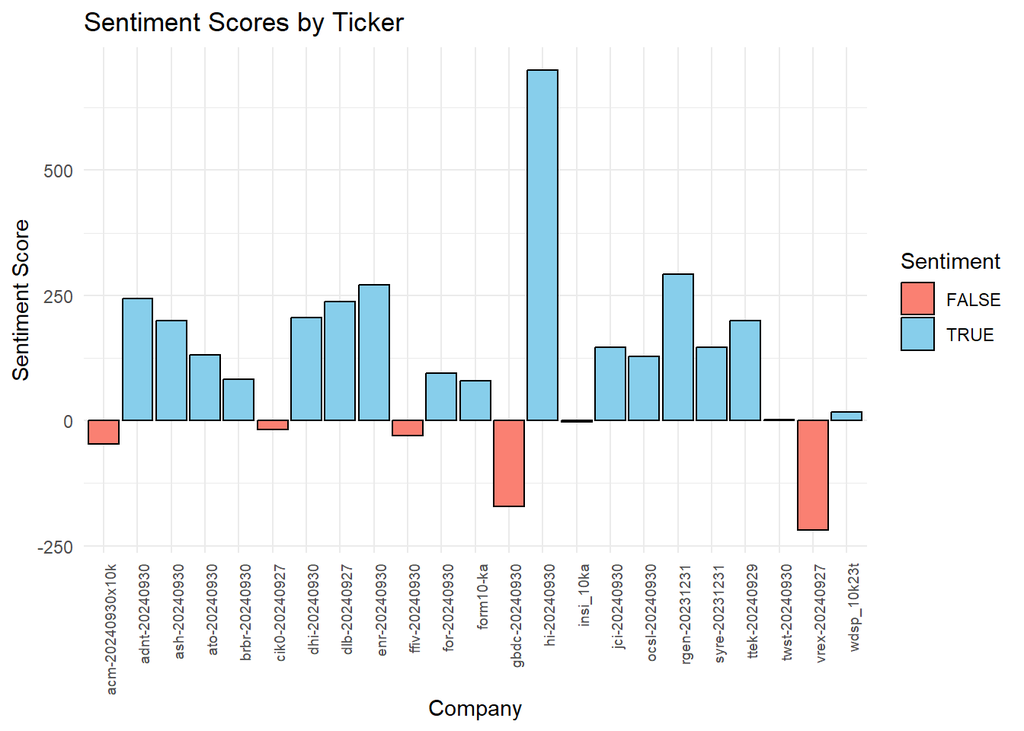

```r
# Plot sentiment scores
ggplot(sentiment_df, aes(x = extracted_name, y = sentiment_score, fill = sentiment_score > 0)) +
  geom_bar(stat = "identity", color = "black") +
  scale_fill_manual(values = c("TRUE" = "skyblue", "FALSE" = "salmon")) +
  labs(
    title = "Sentiment Scores by Ticker",
    x = "Company",
    y = "Sentiment Score",
    fill = "Sentiment"
  ) +
  theme_minimal() +
  theme(axis.text.x = element_text(size = 7, angle = 90, hjust = 1))
```

## Identifying Top Positive and Negative Words

Identifies the top 10 positive and negative words across all documents. Creates a combined bar plot to display the most frequent positive and negative words.

```r
word_sentiment_df <- analyze_df %>%
  inner_join(get_sentiments("bing"), by = "word")

# Top 10 most positive words
top_positive_words <- word_sentiment_df %>%
  filter(sentiment == "positive") %>%  # Filter positive words
  count(word, sort = TRUE) %>%         # Count occurrences
  slice_max(n, n = 10)                 # Get the top 10

# Top 10 most negative words
top_negative_words <- word_sentiment_df %>%
  filter(sentiment == "negative") %>%  # Filter negative words
  count(word, sort = TRUE) %>%         # Count occurrences
  slice_max(n, n = 10)                 # Get the top 10

# View results
top_positive_words
```

```
## # A tibble: 10 × 2
##    word              n
##    <chr>         <int>
##  1 fair           2495
##  2 significant    1324
##  3 outstanding    1032
##  4 effective       838
##  5 benefit         701
##  6 comprehensive   639
##  7 benefits        576
##  8 goodwill        570
##  9 gains           563
## 10 restructuring   540
```

```r
top_negative_words
```

```
## # A tibble: 10 × 2
##    word           n
##    <chr>      <int>
##  1 debt        2178
##  2 loss        1693
##  3 risk        1371
##  4 risks        997
##  5 liability    837
##  6 losses       805
##  7 limited      730
##  8 restricted   661
##  9 adverse      579
## 10 gross        461
```

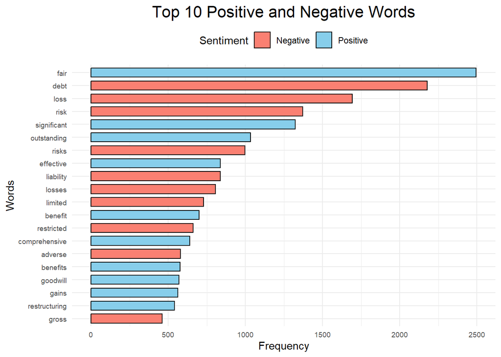

```r
# Combine positive and negative word data for plotting
top_words <- bind_rows(
  top_positive_words %>% mutate(sentiment = "Positive"),
  top_negative_words %>% mutate(sentiment = "Negative")
)

# Create the bar plot
ggplot(top_words, aes(x = reorder(word, n), y = n, fill = sentiment)) +
  geom_bar(stat = "identity", color = "black", width = 0.7) +
  coord_flip() +  # Flip coordinates for better readability
  labs(
    title = "Top 10 Positive and Negative Words",
    x = "Words",
    y = "Frequency",
    fill = "Sentiment"
  ) +
  scale_fill_manual(values = c("Positive" = "skyblue", "Negative" = "salmon")) +
  theme_minimal() +
  theme(
    plot.title = element_text(hjust = 0.5, size = 16),
    axis.text.x = element_text(size = 7),
    axis.text.y = element_text(size = 7),
    legend.position = "top"
  )
```

## Top Words for Highest Sentiment

Filters the documents with the highest sentiment scores. Creates a faceted bar plot showing the top 5 words (positive and negative) for each of these documents.

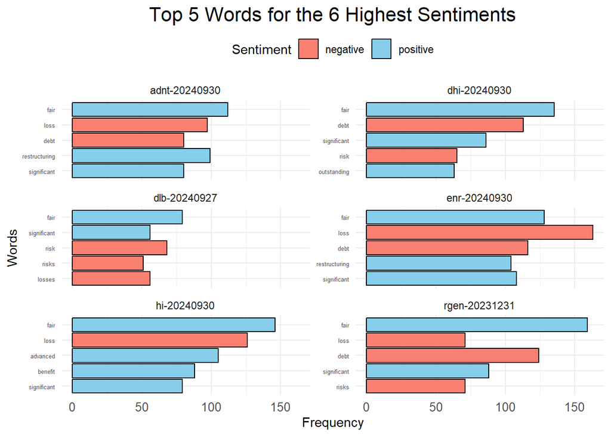

```r
top_extracted_names <- sentiment_df %>%
  arrange(desc(sentiment_score)) %>%
  slice_head(n = 6) %>%
  pull(extracted_name)

# Filter words for these top extracted_name entries
word_sentiment_top <- analyze_df %>%
  inner_join(get_sentiments("bing"), by = "word") %>%
  filter(extracted_name %in% top_extracted_names) %>%
  count(extracted_name, word, sentiment, sort = TRUE) %>%
  group_by(extracted_name) %>%
  slice_max(n, n = 5) %>%  # Get top 10 words for each extracted_name
  ungroup()

# Create a faceted bar plot
ggplot(word_sentiment_top, aes(x = reorder(word, n), y = n, fill = sentiment)) +
  geom_bar(stat = "identity", color = "black") +
  coord_flip() +
  facet_wrap(~ extracted_name, scales = "free_y", ncol = 2) +
  labs(
    title = "Top 5 Words for the 6 Highest Sentiments",
    x = "Words",
    y = "Frequency",
    fill = "Sentiment"
  ) +
  scale_fill_manual(values = c("positive" = "skyblue", "negative" = "salmon")) +
  theme_minimal() +
  theme(
    plot.title = element_text(hjust = 0.5, size = 16),
    axis.text.x = element_text(size = 10),
    axis.text.y = element_text(size = 5),
    legend.position = "top"
  )
```

## Bigram Analysis

Tokenizes the text into bigrams (two-word phrases). Removes both generic stop words and custom stop words to focus on actionable phrases. Visualizes the top 20 bigrams in a bar plot.

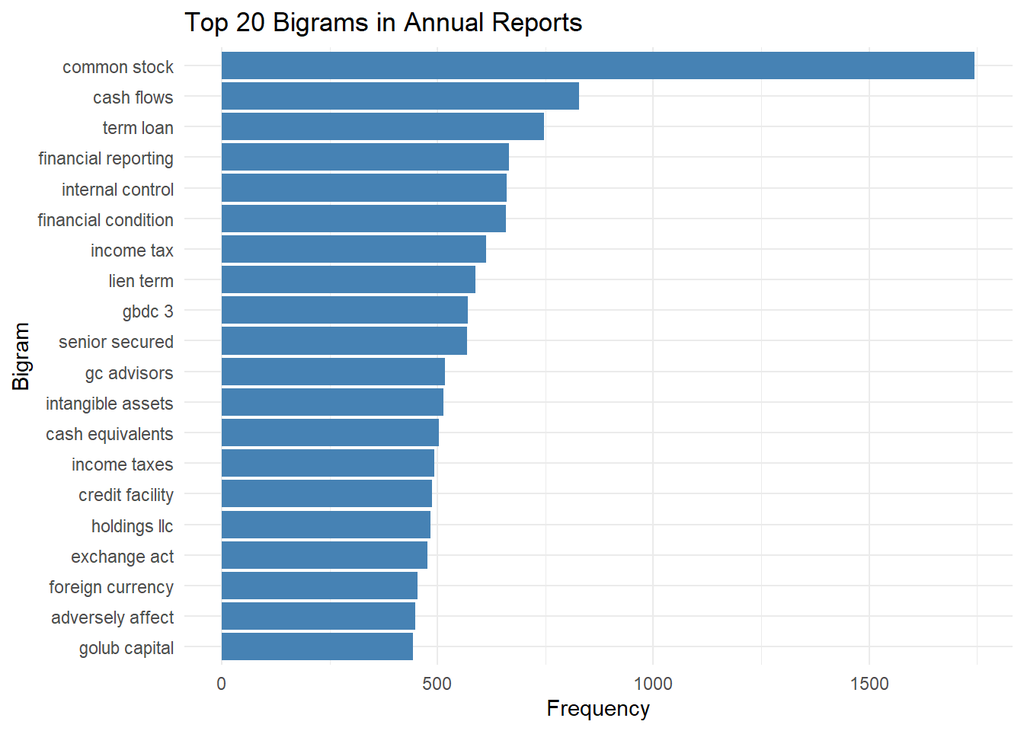

```r
# Define a custom list of stop words to exclude generic terms and date-related words
custom_stop_words <- c(
  "september", "30", "2024", "31", "2023", "fiscal",
  "december", "form", "annual", "report", "form 10", "statement", "consolidated financial", "consolidated", "statements"
)

# Tokenize into bigrams, filter out custom stop words
bigram_df <- processed_df %>%
  unnest_tokens(bigram, df, token = "ngrams", n = 2) %>%
  separate(bigram, into = c("word1", "word2"), sep = " ") %>%
  filter(!is.na(word1), !is.na(word2)) %>%
  filter(!word1 %in% stop_words$word, !word2 %in% stop_words$word) %>%  # Exclude general stop words
  filter(!word1 %in% custom_stop_words, !word2 %in% custom_stop_words) %>%  # Exclude custom stop words
  count(word1, word2, sort = TRUE)

# Plot the top 20 actionable bigrams
bigram_df %>%
  slice_max(n, n = 20) %>%
  unite(bigram, word1, word2, sep = " ") %>%
  ggplot(aes(x = reorder(bigram, n), y = n)) +
  geom_bar(stat = "identity", fill = "steelblue") +
  coord_flip() +
  labs(
    title = "Top 20 Bigrams in Annual Reports",
    x = "Bigram",
    y = "Frequency"
  ) +
  theme_minimal()
```

## Topic Modeling

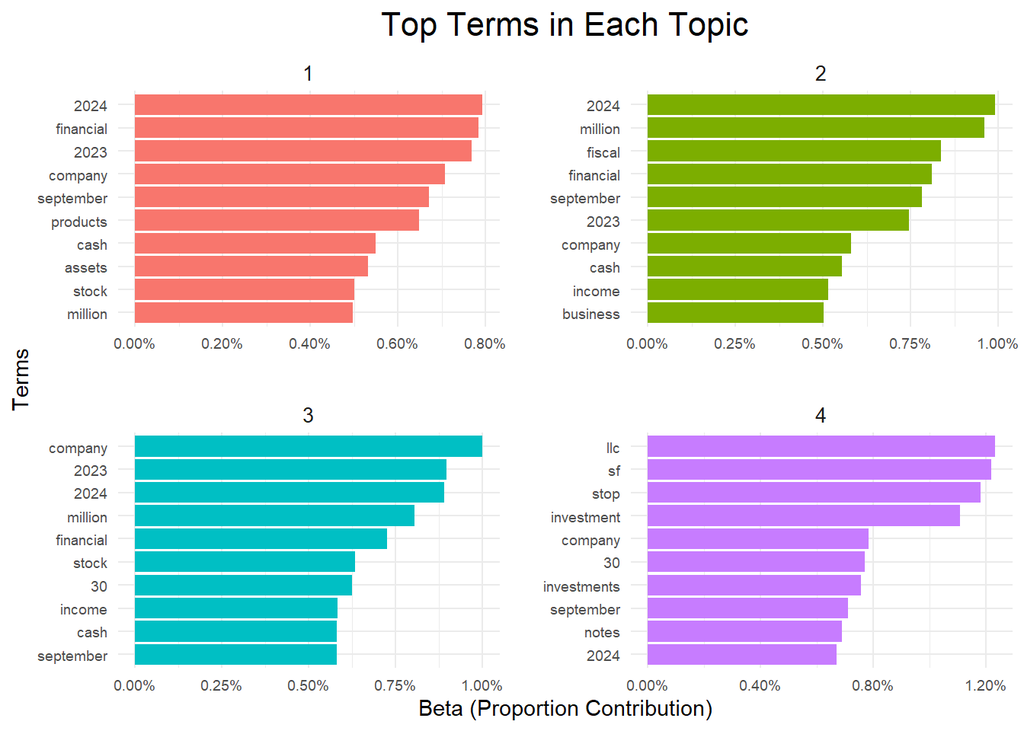

```r
# Create a document-term matrix
dtm <- analyze_df %>%
  count(extracted_name, word) %>%
  cast_dtm(extracted_name, word, n)

# Apply LDA with 4 topics
lda_model <- LDA(dtm, k = 4, control = list(seed = 1234))

# Extract topics
topics <- tidy(lda_model, matrix = "beta")

# Get top terms for each topic
top_terms <- topics %>%
  group_by(topic) %>%
  slice_max(beta, n = 10) %>%
  ungroup() %>%
  arrange(topic, desc(beta))

# Plot top terms per topic
top_terms %>%
  mutate(term = reorder_within(term, beta, topic)) %>%
  ggplot(aes(x = term, y = beta, fill = factor(topic))) +
  geom_bar(stat = "identity", show.legend = FALSE) +  # Hide legend if not needed
  coord_flip() +
  facet_wrap(~ topic, scales = "free", ncol = 2, strip.position = "top") +  # Adjust layout
  scale_x_reordered() +
  scale_y_continuous(labels = scales::percent_format(accuracy = 0.01)) +  # Format beta as percentage
  labs(
    title = "Top Terms in Each Topic",
    x = "Terms",
    y = "Beta (Proportion Contribution)"
  ) +
  theme_minimal() +
  theme(
    plot.title = element_text(hjust = 0.5, size = 16),
    axis.text.x = element_text(size = 7),  # Set x-axis text size
    axis.text.y = element_text(size = 7),  # Set y-axis text size
    strip.text = element_text(size = 10),  # Facet strip text size
    panel.spacing = unit(1.5, "lines")  # Add space between facets
  )
```

#### Sentiment Analysis Insights

Implications: These companies are likely emphasizing favorable financial results, growth opportunities, or overall stability. Stakeholders (e.g., investors, creditors) might perceive these companies as lower-risk, making them attractive for investment or lending.

Action: Analyze these reports further to understand the drivers of positive sentiment, such as significant revenue growth or successful investments. Consider these companies as benchmarks for understanding effective communication strategies in annual reports.

Implications: These companies may be facing operational or financial challenges, such as declining revenues, litigation risks, or unfavorable market conditions. Potential risks for stakeholders could include increased volatility or the need for restructuring.

Action: Investigate the specific sections of their reports contributing to the negative sentiment (e.g., “Risk Factors,” “Management Discussion and Analysis”). Monitor these companies closely for turnaround strategies or further declines.

#### Keyword Frequency Insights

Positive Words: Fair, Significant, Outstanding are the most frequent positive terms.

Implications: Companies are emphasizing fairness (likely in valuation or governance), significance (in decisions, acquisitions, or partnerships), and outstanding performance.

Action: Look for specific contexts where these words appear to understand how companies frame their successes. Ensure reports balance positive framing with realistic assessments to maintain credibility.

Negative Words: Debt, Risk, Loss are the most frequent negative terms.

Implications: Companies may be struggling with high leverage (debt), exposure to risks (market, regulatory, or operational), or financial losses. Frequent use of these terms could indicate sectors under pressure (e.g., oil and gas, tech startups, or sectors with cyclical demand).

Action: Identify sectors or companies where these terms dominate to evaluate whether risks are being actively managed or escalating. Advise companies to provide clear mitigation strategies alongside mentions of risks to reassure stakeholders.

#### Balance Sheet Related:

Indicates a strong focus on financial position, liabilities, and equity.

Action: Analyze companies with high mentions of this topic to assess leverage, liquidity, and solvency trends.

#### Income Statement Related:

Focus on revenue, expenses, and profitability.

Action: Identify growth drivers (new markets, cost efficiencies) or hindrances (declining margins).

#### Cash Flow Related:

Highlights operational efficiency and liquidity.

Action: Evaluate cash flow health for investment capacity or sustainability in operations.

#### Investments and Business Types:

Emphasis on strategic priorities, acquisitions, or core business areas.

Action: Use this information to categorize companies by strategic focus (growth-oriented vs. consolidation-focused). Monitor how investment narratives align with actual performance metrics. Holistic Insights and Recommendations

#### Sentiment-Performance Correlation:

Companies with high sentiment and strong financials are likely well-positioned, while low sentiment combined with poor performance could signal distress.

Recommendation: For stakeholders, prioritize companies with high sentiment and performance alignment for investment opportunities.

#### Communication Strategies:

Companies with high positive sentiment (hi-20240930) may have strong communication strategies, effectively framing challenges and opportunities.

Recommendation: Shareholders and executives should benchmark these reports to refine their own communication practices.

#### Risk Monitoring:

Frequent mentions of negative terms like debt and loss warrant closer scrutiny of financial sustainability.

Recommendation: Develop risk heat maps to monitor companies/sectors with the highest prevalence of negative terms for proactive intervention.

#### Sector Analysis:

Balance sheet, income statement, and cash flow focus suggest companies are heavily engaged in financial reporting.

Recommendation: Use topic distribution to compare sectors and identify trends, such as which sectors focus more on balance sheets (indicating stability) versus income statements (growth focus).

#### Stakeholder Communication:

Positive framing with transparency: Companies should balance showcasing strengths (outstanding growth) with transparent discussions of risks (debt management).